# Workshop 10: Time

Download the link to the quarto template here

Download lab10_soln.qmd

## Introduction

The goal of today’s workshop is to explore data related to time.

Specifically we will:

- understand some challenges and techniques for wrangling data with time
- adapt techniques for visualizations to data collected over time

## So simple yet so complicated

At first glance, dates and times seem simple. You use them all the time in, and they don’t seem to cause much confusion. However, the more you learn about dates and times, the more complicated they seem to get!

As a warm-up think about the different ways people write the date. How many different ways can you think of?

When might you record dates?

## Dates lubridate

We will be using the package `lubridate` as part of the `tidyverse` and taking advantage of their built in data.

```r
library(tidyverse)
library(nycflights13)
```

## Creating date/times

We are going to focus on dates and date-times.

R doesn’t have a native class for storing times. If you need one, you can use the `hms` package.

## General rule of thumb

You should always use the simplest possible data type that works for your needs. That means if you can use a date instead of a date-time, you should. Date-times are substantially more complicated because of the need to handle time zones.

That’s right don’t forget about time zones!

### Try yourself

Get the date using `today()`

Get the date-time using `now()`

```r
today()
```

```
[1] "2026-10-02"
```

```r
now()
```

```
[1] "2026-10-02 16:43:51 NZDT"
```

## Year Month day

[output not shown]

## Data wrangling: words of caution

People who enter data make mistakes

People who enter data do not always follow instructions

Poeple who enter data may not be the person/people who analyse that data or any data (they may never know your pain)

## Data wrangling

Sometimes you’ll have the individual components of the date-time spread across multiple columns

```r
flights |>
  select(year, month, day, hour, minute)
```

```
# A tibble: 336,776 × 5
    year month   day  hour minute
   <int> <int> <int> <dbl>  <dbl>
 1  2013     1     1     5     15
 2  2013     1     1     5     29
 3  2013     1     1     5     40
 4  2013     1     1     5     45
 5  2013     1     1     6      0
 6  2013     1     1     5     58
 7  2013     1     1     6      0
 8  2013     1     1     6      0
 9  2013     1     1     6      0
10  2013     1     1     6      0
# ℹ 336,766 more rows
```

## Data wrangle: make a date

Let’s make a date out of the time columns in `flights`.

```r
flights |>
  select(year, month, day, hour, minute) |>
  mutate(departure = make_date(year, month, day))
```

```
# A tibble: 336,776 × 6
    year month   day  hour minute departure
   <int> <int> <int> <dbl>  <dbl> <date>
 1  2013     1     1     5     15 2013-01-01
 2  2013     1     1     5     29 2013-01-01
 3  2013     1     1     5     40 2013-01-01
 4  2013     1     1     5     45 2013-01-01
 5  2013     1     1     6      0 2013-01-01
 6  2013     1     1     5     58 2013-01-01
 7  2013     1     1     6      0 2013-01-01
 8  2013     1     1     6      0 2013-01-01
 9  2013     1     1     6      0 2013-01-01
10  2013     1     1     6      0 2013-01-01
# ℹ 336,766 more rows
```

### Try yourself

Repeat the above code to make a departure column with date and time. Use the function `make_datetime()`.

```r
flights |>
  select(year, month, day, hour, minute) |>
  mutate(dep_data_time = make_datetime(year, month, day,  hour, minute))
```

```
# A tibble: 336,776 × 6
    year month   day  hour minute dep_data_time
   <int> <int> <int> <dbl>  <dbl> <dttm>
 1  2013     1     1     5     15 2013-01-01 05:15:00
 2  2013     1     1     5     29 2013-01-01 05:29:00
 3  2013     1     1     5     40 2013-01-01 05:40:00
 4  2013     1     1     5     45 2013-01-01 05:45:00
 5  2013     1     1     6      0 2013-01-01 06:00:00
 6  2013     1     1     5     58 2013-01-01 05:58:00
 7  2013     1     1     6      0 2013-01-01 06:00:00
 8  2013     1     1     6      0 2013-01-01 06:00:00
 9  2013     1     1     6      0 2013-01-01 06:00:00
10  2013     1     1     6      0 2013-01-01 06:00:00
# ℹ 336,766 more rows
```

Notice that seconds is filled in even though I did not specify that data.

### Try yourself

But we also have other ‘date-time’-like columns in the flights dataset

Explore these columns, what type of data do they contain.

```r
glimpse(flights)
```

```
Rows: 336,776
Columns: 19
$ year           <int> 2013, 2013, 2013, 2013, 2013, 2013, 2013, 2013, 2013, 2…
$ month          <int> 1, 1, 1, 1, 1, 1, 1, 1, 1, 1, 1, 1, 1, 1, 1, 1, 1, 1, 1…
$ day            <int> 1, 1, 1, 1, 1, 1, 1, 1, 1, 1, 1, 1, 1, 1, 1, 1, 1, 1, 1…
$ dep_time       <int> 517, 533, 542, 544, 554, 554, 555, 557, 557, 558, 558, …
$ sched_dep_time <int> 515, 529, 540, 545, 600, 558, 600, 600, 600, 600, 600, …
$ dep_delay      <dbl> 2, 4, 2, -1, -6, -4, -5, -3, -3, -2, -2, -2, -2, -2, -1…
$ arr_time       <int> 830, 850, 923, 1004, 812, 740, 913, 709, 838, 753, 849,…
$ sched_arr_time <int> 819, 830, 850, 1022, 837, 728, 854, 723, 846, 745, 851,…
$ arr_delay      <dbl> 11, 20, 33, -18, -25, 12, 19, -14, -8, 8, -2, -3, 7, -1…
$ carrier        <chr> "UA", "UA", "AA", "B6", "DL", "UA", "B6", "EV", "B6", "…
$ flight         <int> 1545, 1714, 1141, 725, 461, 1696, 507, 5708, 79, 301, 4…
$ tailnum        <chr> "N14228", "N24211", "N619AA", "N804JB", "N668DN", "N394…
$ origin         <chr> "EWR", "LGA", "JFK", "JFK", "LGA", "EWR", "EWR", "LGA",…
$ dest           <chr> "IAH", "IAH", "MIA", "BQN", "ATL", "ORD", "FLL", "IAD",…
$ air_time       <dbl> 227, 227, 160, 183, 116, 150, 158, 53, 140, 138, 149, 1…
$ distance       <dbl> 1400, 1416, 1089, 1576, 762, 719, 1065, 229, 944, 733, …
$ hour           <dbl> 5, 5, 5, 5, 6, 5, 6, 6, 6, 6, 6, 6, 6, 6, 6, 5, 6, 6, 6…
$ minute         <dbl> 15, 29, 40, 45, 0, 58, 0, 0, 0, 0, 0, 0, 0, 0, 0, 59, 0…
$ time_hour      <dttm> 2013-01-01 05:00:00, 2013-01-01 05:00:00, 2013-01-01 0…
```

## Flight times

The departure and arrival times are represented in an odd format,

```r
glimpse(flights$dep_time)
```

```
 int [1:336776] 517 533 542 544 554 554 555 557 557 558 ...
```

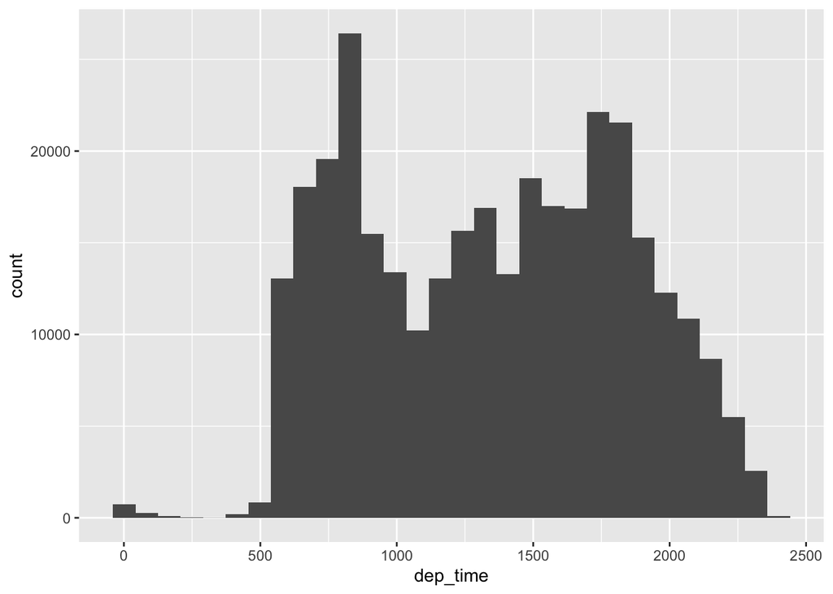

```r
flights |>
  ggplot()+
  aes( x = dep_time)+
  geom_histogram()
```

so we can modulus arithmetic to pull out the hour and minute components

```r
make_datetime_100 <- function(year, month, day, time) {
  make_datetime(year, month, day, time %/% 100, time %% 100)
}

flights_dt <- flights |>
  filter(!is.na(dep_time), !is.na(arr_time)) |>
  mutate(
    dep_time = make_datetime_100(year, month, day, dep_time),
    arr_time = make_datetime_100(year, month, day, arr_time),
    sched_dep_time = make_datetime_100(year, month, day, sched_dep_time),
    sched_arr_time = make_datetime_100(year, month, day, sched_arr_time)
  ) |>
  select(origin, dest, ends_with("delay"), ends_with("time"))

glimpse(flights_dt)
```

```
Rows: 328,063
Columns: 9
$ origin         <chr> "EWR", "LGA", "JFK", "JFK", "LGA", "EWR", "EWR", "LGA",…
$ dest           <chr> "IAH", "IAH", "MIA", "BQN", "ATL", "ORD", "FLL", "IAD",…
$ dep_delay      <dbl> 2, 4, 2, -1, -6, -4, -5, -3, -3, -2, -2, -2, -2, -2, -1…
$ arr_delay      <dbl> 11, 20, 33, -18, -25, 12, 19, -14, -8, 8, -2, -3, 7, -1…
$ dep_time       <dttm> 2013-01-01 05:17:00, 2013-01-01 05:33:00, 2013-01-01 0…
$ sched_dep_time <dttm> 2013-01-01 05:15:00, 2013-01-01 05:29:00, 2013-01-01 0…
$ arr_time       <dttm> 2013-01-01 08:30:00, 2013-01-01 08:50:00, 2013-01-01 0…
$ sched_arr_time <dttm> 2013-01-01 08:19:00, 2013-01-01 08:30:00, 2013-01-01 0…
$ air_time       <dbl> 227, 227, 160, 183, 116, 150, 158, 53, 140, 138, 149, 1…
```

## Simple line graph

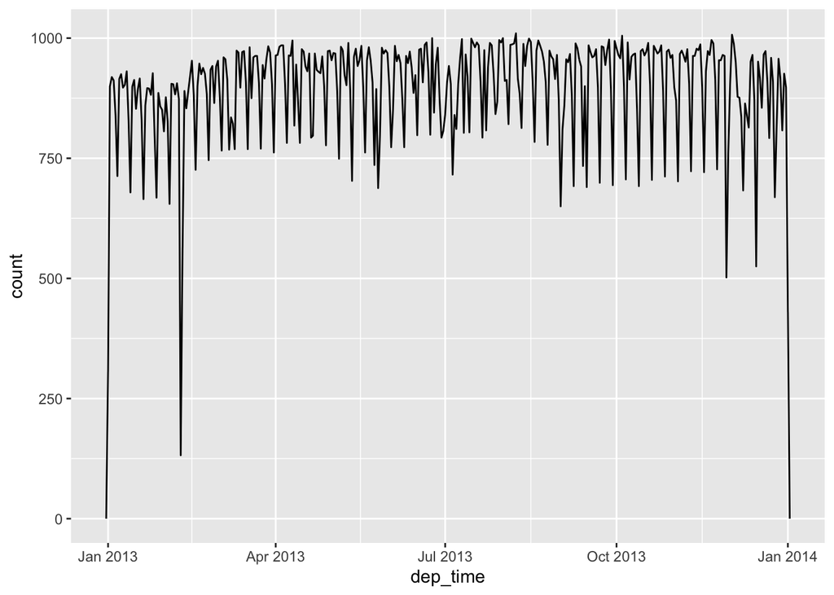

```r
# over the year
flights_dt |>
  ggplot(aes(x = dep_time)) +
  geom_freqpoly(binwidth = 86400)
```

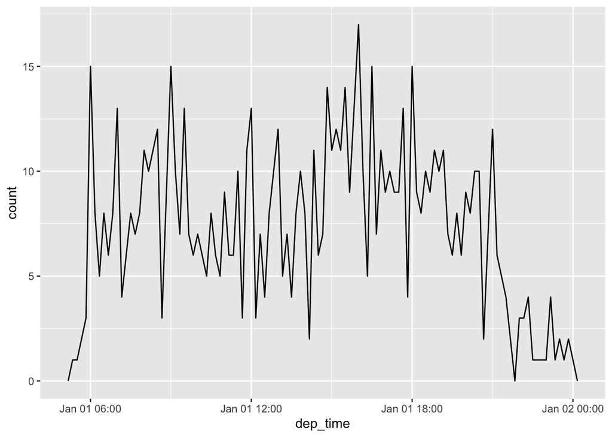

```r
# in a single day
flights_dt |>
  filter(dep_time < ymd(20130102)) |>
  ggplot(aes(x = dep_time)) +
  geom_freqpoly(binwidth = 600) # 600 s = 10 minutes
```

### Try yourself

Add a categorical variable to your graph, think about whether it might be useful as a shape, color, or facet.

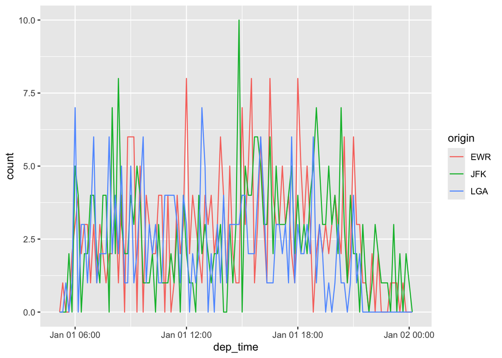

```r
flights_dt |>
  filter(dep_time < ymd(20130102)) |>
  ggplot(aes(x = dep_time, color = origin)) +
  geom_freqpoly(binwidth = 600) # 600 s = 10 minutes
```

Not a great option. Faceting is better, see below.

## Facet option

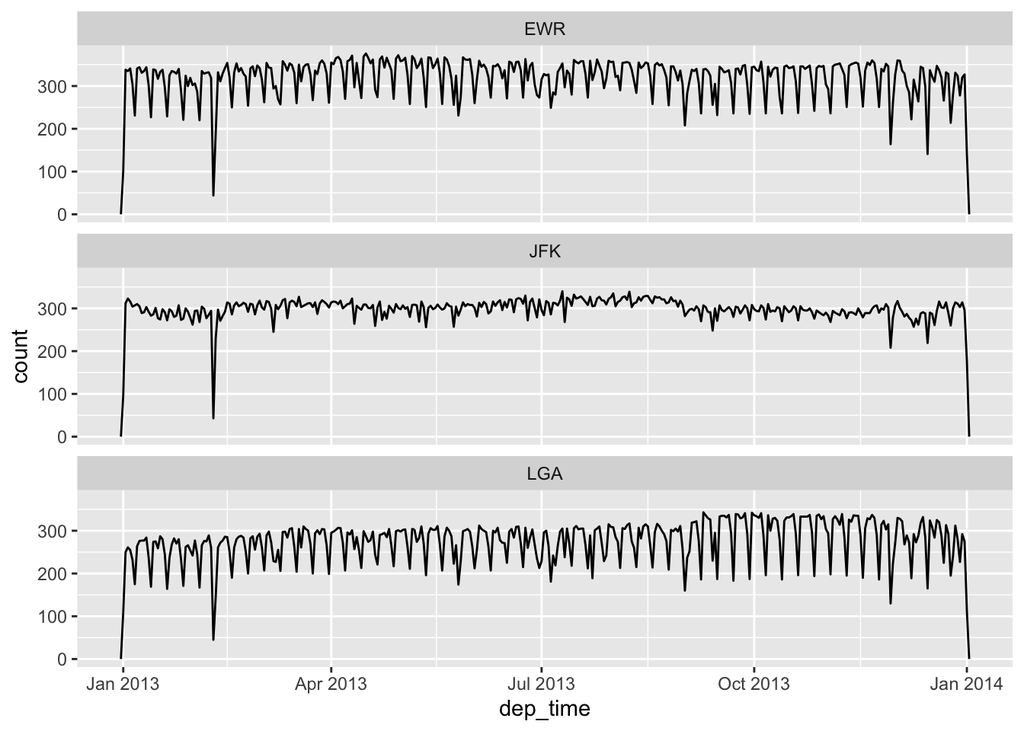

```r
flights_dt |>
  ggplot(aes(x = dep_time)) +
  geom_freqpoly(binwidth = 86400) +
  facet_wrap(. ~ origin, ncol = 1)
```

## Getting components

Sometimes you are given the `data-time` type of data and may want to display just years, days, or even something new like days of the week.

You can pull out individual parts of the date with the accessor functions `year()`, `month()`, `mday()` (day of the month), `yday()` (day of the year), `wday()` (day of the week), `hour()`, `minute()`, and `second()`. These are effectively the opposites of `make_datetime()`.

### Try yourself

Given this code:

```r
datetime <- ymd_hms("2026-07-08 12:34:56")
```

Extract the year, month, day, and weekday.

```r
year(datetime)
```

```
[1] 2026
```

```r
month(datetime)
```

```
[1] 7
```

```r
day(datetime)
```

```
[1] 8
```

```r
wday(datetime)
```

```
[1] 4
```

Try `month()` and `wday()` you can set `label = TRUE` to return the abbreviated name of the month or day of the week. Set `abbr = FALSE` to return the full name.

```r
month(datetime, label = TRUE)
```

```
[1] Jul
12 Levels: Jan < Feb < Mar < Apr < May < Jun < Jul < Aug < Sep < ... < Dec
```

```r
month(datetime, label = TRUE, abbr = FALSE)
```

```
[1] July
12 Levels: January < February < March < April < May < June < ... < December
```

```r
wday(datetime, label = TRUE)
```

```
[1] Wed
Levels: Sun < Mon < Tue < Wed < Thu < Fri < Sat
```

## Days of the week

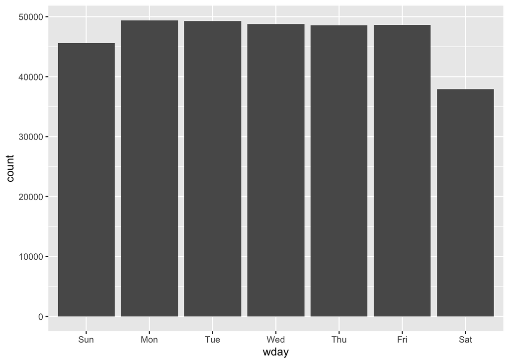

```r
flights_dt |>
  mutate(wday = wday(dep_time, label = TRUE)) |>
  ggplot(aes(x = wday)) +
  geom_bar()
```

## Exploring patterns over time

We can also look at the average departure delay by minute within the hour

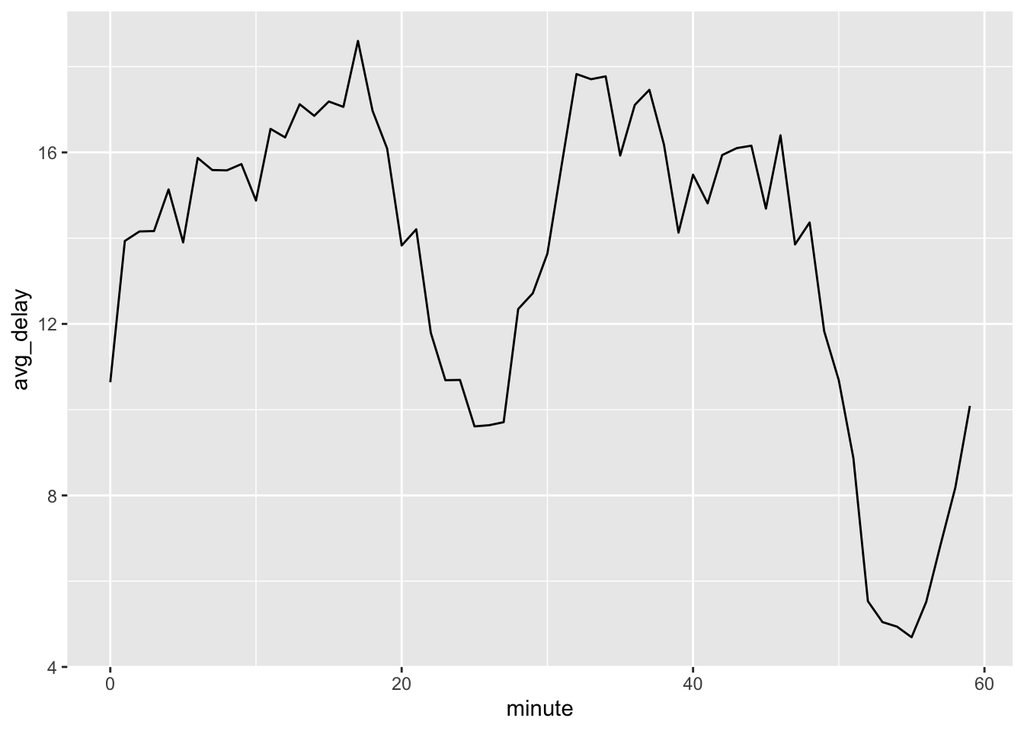

```r
flights_dt |>
  mutate(minute = minute(dep_time)) |>
  group_by(minute) |>
  summarize(
    avg_delay = mean(dep_delay, na.rm = TRUE),
    n = n()
  ) |>
  ggplot(aes(x = minute, y = avg_delay)) +
  geom_line()
```

Notice any patterns?

### Try yourself

Repeat the above graph with scheduled departure time, is there the same pattern?

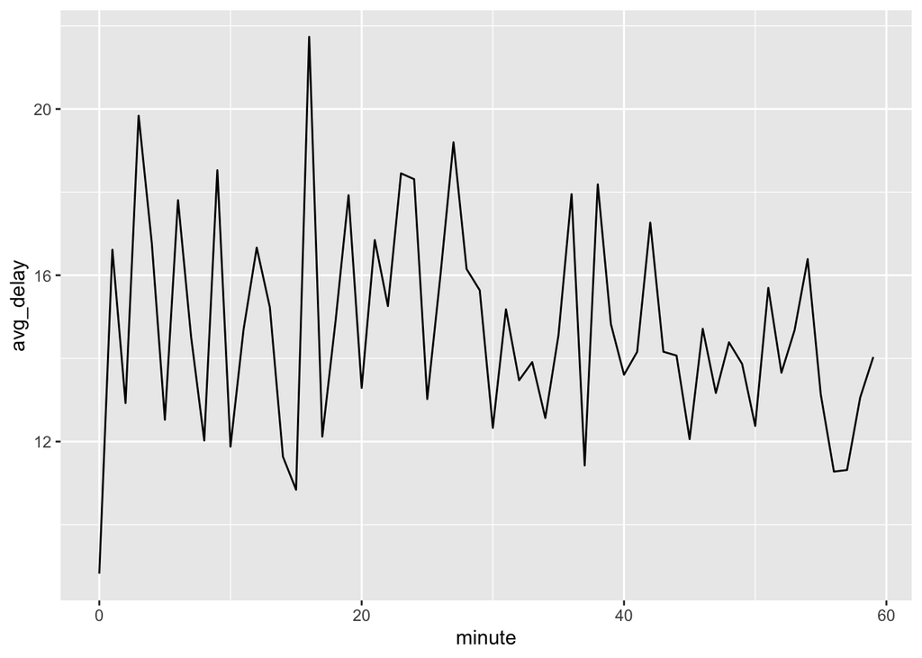

```r
flights_dt |>
  mutate(minute = minute(sched_dep_time)) |>
  group_by(minute) |>
  summarize(
    avg_delay = mean(dep_delay, na.rm = TRUE),
    n = n()
  ) |>
  ggplot(aes(x = minute, y = avg_delay)) +
  geom_line()
```

Not really a pattern in delays given scheduled departure time.

### Try yourself

Now create a frequency polygon graph showing the number of flights scheduled to depart each hour. Notice any patterns?

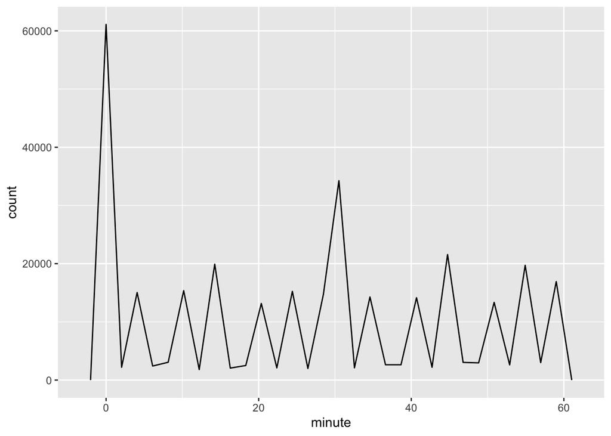

```r
flights_dt |>
  mutate(minute = minute(sched_dep_time)) |>
  ggplot(aes(x = minute)) +
  geom_freqpoly()
```

Now there are some peaks: on the hour and 30 min past.

## What is happening?

Humans

here’s a strong bias towards flights leaving at “nice” departure times

Always be alert for this sort of pattern whenever you work with data that involves human judgement!

Look out for number biases like culturally significant numbers, ‘lucky’ numbers, and preference for round numbers.

What to do? do not over interpret data

## Economics

We are now going to work with the `economics` dataset in ggplot

```r
data(economics, package = 'ggplot2')
```

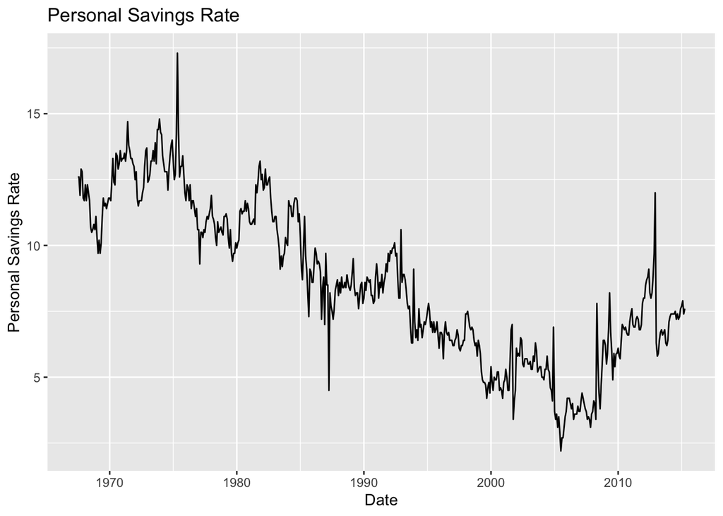

```r
ggplot(economics) +
  aes(x = date, y = psavert) +
  geom_line() +
  labs(title = "Personal Savings Rate",
       x = "Date",
       y = "Personal Savings Rate")
```

produced from US economic time series data available from https://fred.stlouisfed.org/.

## Date format with scale_x_date

We can jazz up the previous graph

`scale_x_date()` function from scales package can be used to reformat dates.

This is essentially mutating the data but only in the plot so the original data remains the same.

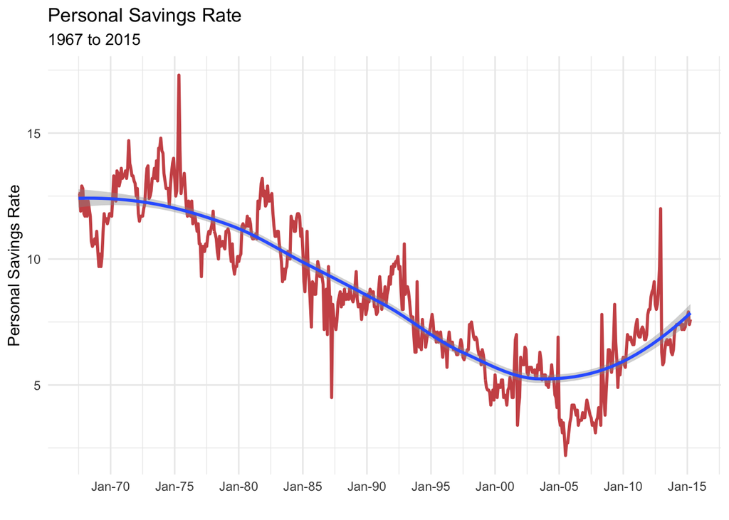

```r
ggplot(economics) +
  aes(x = date, y = psavert) +
  geom_line(color = "indianred3",
            size=1 ) +
  geom_smooth() +
  scale_x_date(date_breaks = '5 year',
               labels = scales::label_date(format = "%b-%y")) +
  labs(title = "Personal Savings Rate",
       subtitle = "1967 to 2015",
       x = "",
       y = "Personal Savings Rate") +
  theme_minimal()
```

## scale_*_date Function

`scale_x_date()` `scale_y_date()` from `scales` package (part of tidyverse)

Main parameters: `date_breaks()` `labels = label_date()`

`date_breaks()` is used to set the positions of the tick marks on the x-axis of a plot

`date_breaks()` function takes one argument, which is the unit of time

For example:

`date_breaks("1 year")`

`date_breaks("6 months")`

`date_breaks("1 week")`

`date_breaks("10 days")`

## Formatting date labels in plots

`label_date()` function takes a single argument, which is a string that specifies the desired format of the date For example,

`label_date("%Y-%m-%d")`: YYYY-MM-DD

`label_date("%Y")`: YYYY

`label_date("%B")`: Full month name (January, February, etc.)

`label_date("%b")`: Abbreviated month name (Jan, Feb, etc.)

`label_date("%d")`: Two-digit day of the month (01, 02, …, 30, 31)

`label_date("%A")`: Full weekday name (Sunday, Monday, Tuesday, etc.)

`label_date("%a")`: Abbreviated weekday name (Sun, Mon, Tue, etc.)

### Try yourself

Update the previous graph, change the labels to be `YYYY-MM` format. Make sure all axes labels are visible, you may need to adjust things in `theme()`.

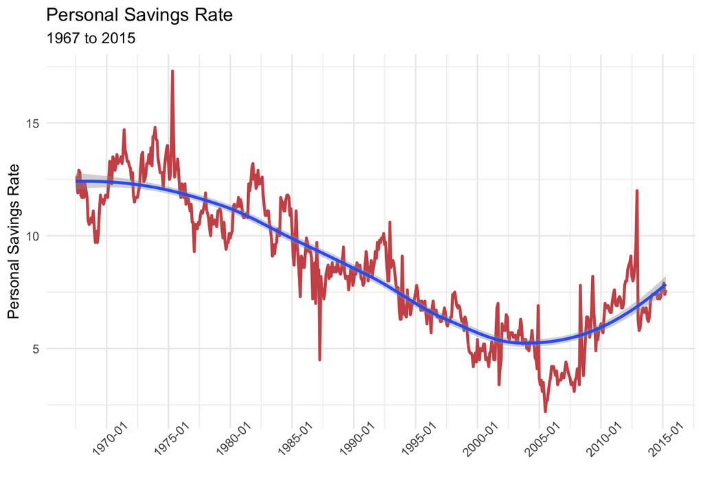

```r
ggplot(economics) +
  aes(x = date, y = psavert) +
  geom_line(color = "indianred3",
            size=1 ) +
  geom_smooth() +
  scale_x_date(date_breaks = '5 year',
               labels = scales::label_date(format = "%Y-%m")) +
  labs(title = "Personal Savings Rate",
       subtitle = "1967 to 2015",
       x = "",
       y = "Personal Savings Rate") +
  theme_minimal() +
  theme(axis.text.x = element_text(angle = 45))
```

## Limits

`scale_x_date` function also takes the argument `limits` if your want to bound your plot without subsetting the data.

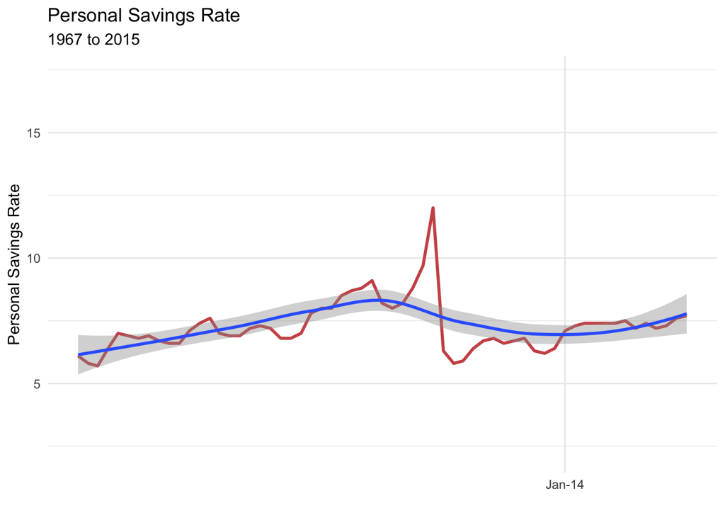

```r
ggplot(economics) +
  aes(x = date, y = psavert) +
  geom_line(color = "indianred3",
            size=1 ) +
  geom_smooth() +
  scale_x_date(date_breaks = '5 year',
               labels = scales::label_date("%b-%y"),
               limit = c(as.Date("2010-01-01"), as.Date("2015-01-01"))) +
  labs(title = "Personal Savings Rate",
       subtitle = "1967 to 2015",
       x = "",
       y = "Personal Savings Rate") +
  theme_minimal()
```

## Breaks

You can add breaks to specify points on the axis.

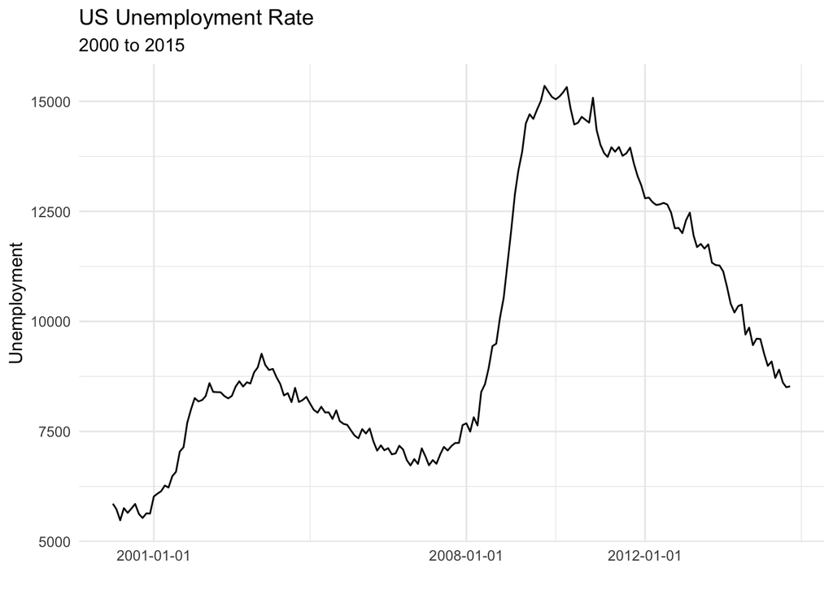

```r
df <- economics[economics$date > as.Date("2000-01-01"), ]

ggplot(df ) +
  aes(x = date, y = unemploy)+
  geom_line() +
   scale_x_date(breaks = c(as.Date("2001-01-01"),
                           as.Date("2008-01-01"),
                           as.Date("2012-01-01")))+
    labs(title = "US Unemployment Rate",
       subtitle = "2000 to 2015",
       x = "",
       y = "Unemployment") +
  theme_minimal()
```

An alternative is to specify the breaks with strings of the format “1 day” (a break each day), “2 months” (a break every two months), “6 years” (a break every six years)…

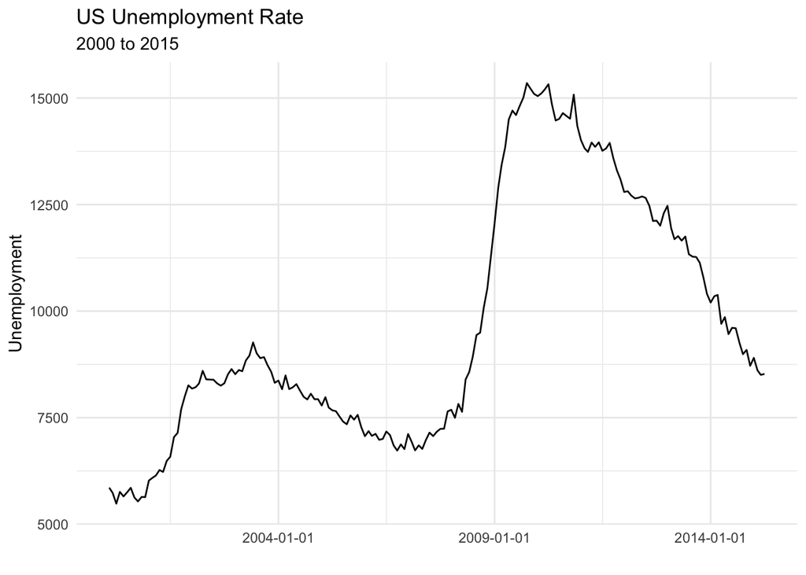

```r
ggplot(df) +
  aes(x = date, y = unemploy)+
  geom_line() +
   scale_x_date(date_breaks = "5 years") +
      labs(title = "US Unemployment Rate",
       subtitle = "2000 to 2015",
       x = "",
       y = "Unemployment") +
  theme_minimal()
```

### Try yourself

Repeat the above graph, adjust the breaks to be 31 Dec (end of financial year in US) of every five years between 2000-2015 (Hint: your axis should have 3 labels).

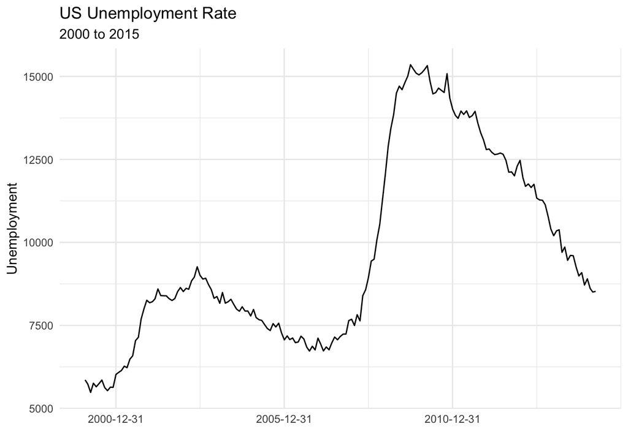

```r
ggplot(df ) +
  aes(x = date, y = unemploy)+
  geom_line() +
   scale_x_date(breaks = c(as.Date("2000-12-31"),
                           as.Date("2005-12-31"),
                           as.Date("2010-12-31")))+
    labs(title = "US Unemployment Rate",
       subtitle = "2000 to 2015",
       x = "",
       y = "Unemployment") +
  theme_minimal()
```

## Highlight changes, peaks and valleys

### add lines to seperate chart

`geom_vline` or `geom_hline` functions to add vertical or horizontal lines, respectively

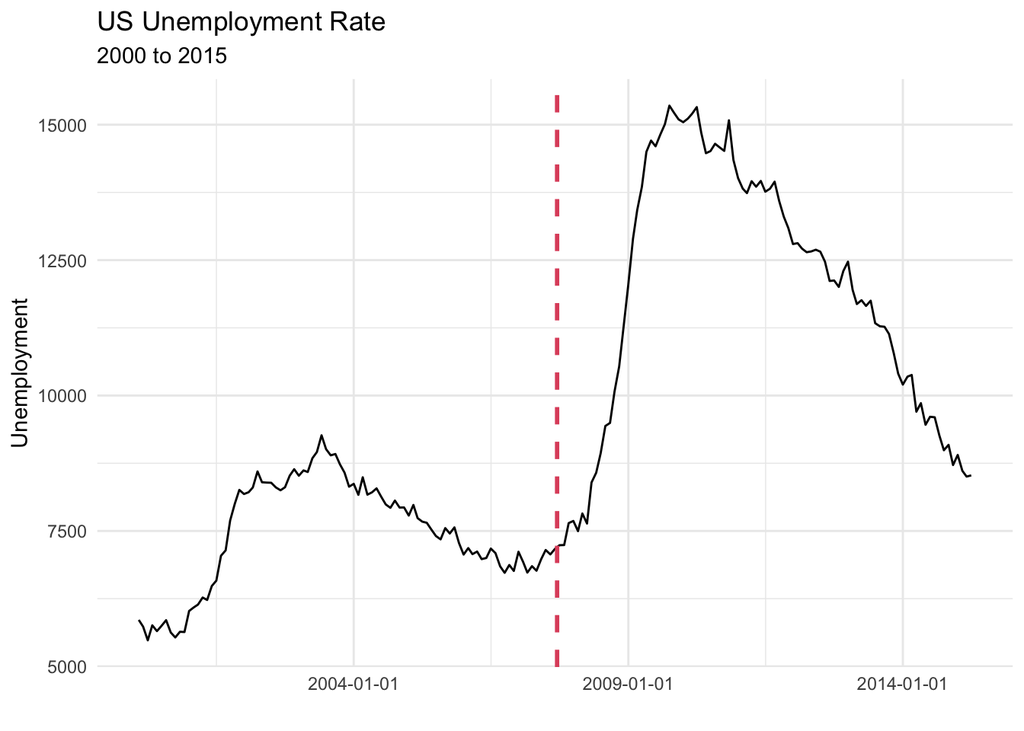

```r
ggplot(df ) +
  aes(x = date, y = unemploy)+
  geom_line() +
  geom_vline(xintercept = as.Date("2007-09-15"),
             linetype = 2, color = 2, linewidth = 1) +
  scale_x_date(date_breaks = "5 years") +
      labs(title = "US Unemployment Rate",
       subtitle = "2000 to 2015",
       x = "",
       y = "Unemployment") +
  theme_minimal()
```

### Peaks and valleys

Add labels to peaks and valleys

`stat_peaks` and `stat_valleys` functions from the `ggpmisc` package you can highlight local maximum or local minimum values based on a span (by default, span = 5)

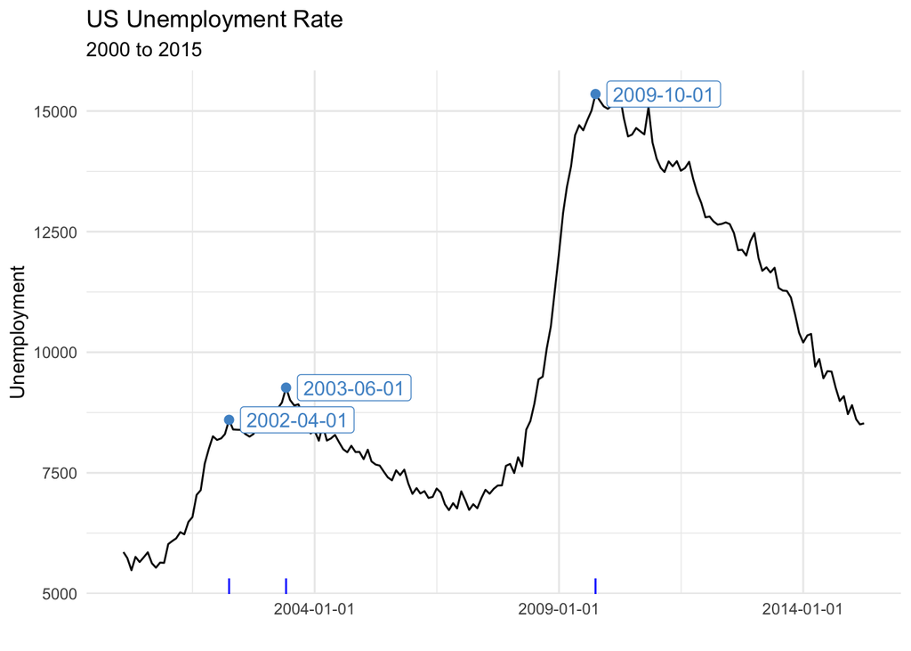

```r
library(ggpmisc)
ggplot(df) +
  aes(x = date, y = unemploy)+
  geom_line() +
  stat_peaks(geom = "point", span = 15, color = "steelblue3", size = 2) +
  stat_peaks(geom = "label", span = 15, color = "steelblue3", angle = 0,
             hjust = -0.1, x.label.fmt = "%Y-%m-%d") +
  stat_peaks(geom = "rug", span = 15, color = "blue", sides = "b")+
  scale_x_date(date_breaks = "5 years") +
      labs(title = "US Unemployment Rate",
       subtitle = "2000 to 2015",
       x = "",
       y = "Unemployment") +
  theme_minimal()
```

As an alternative you can explore `geom_text` or `geom_label` to add labels to your chart without leaving the `tidyverse.`

### Shade areas

With `geom_rect` it is possible to shade some areas of the time series.

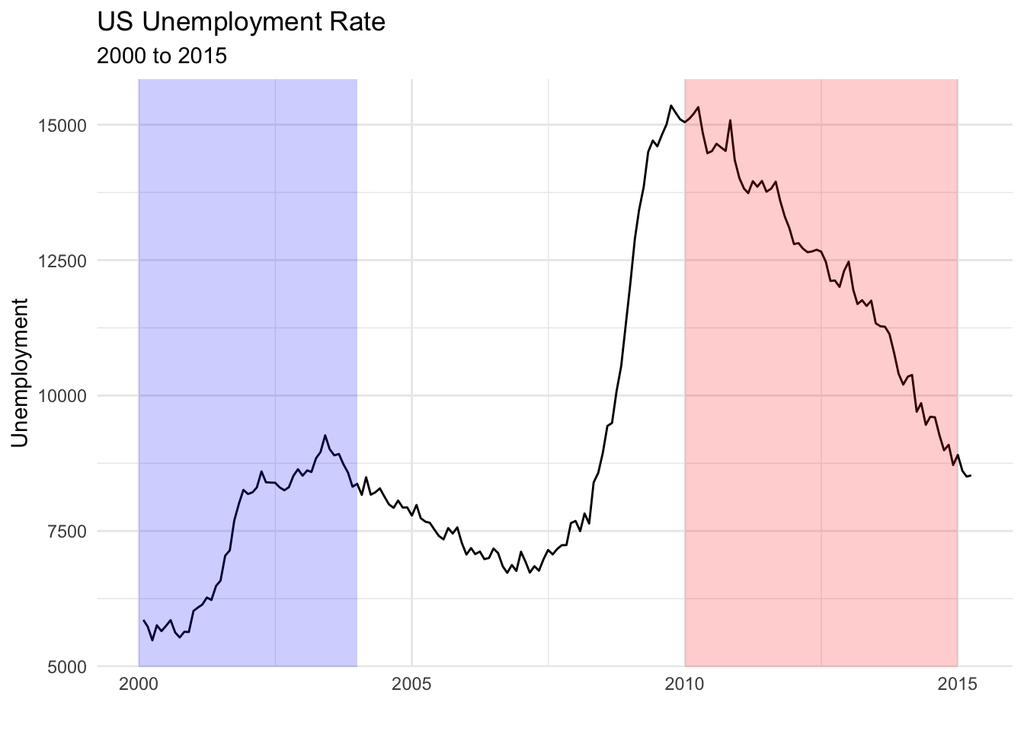

```r
# Shade from 2000 to 2004 and from 2010 to 2015
shade <- data.frame(
  x1 = c(as.Date("2000-01-01"), as.Date("2010-01-01")),
  x2 = c(as.Date("2004-01-01"), as.Date("2015-01-01")),
  min = c(-Inf, -Inf), max = c(Inf, Inf))

ggplot() +
  geom_line(data = df, aes(x = date, y = unemploy)) +
  geom_rect(data = shade, aes(xmin = x1, xmax = x2,
                              ymin = min, ymax = max),
            fill = c("blue", "red"), alpha = 0.2) +
  labs(title = "US Unemployment Rate",
       subtitle = "2000 to 2015",
       x = "",
       y = "Unemployment") +
  theme_minimal()
```

### Try yourself (Challenge!)

The global financial crisis (GFC) took place roughly August 2007-July 2009 in the US. Climax of that crisis was September 15, 2008.

Generate a chart of with unemployment and personal savings rates over time, shade the GFC and add a vertical red bar for the climax of that crisis.

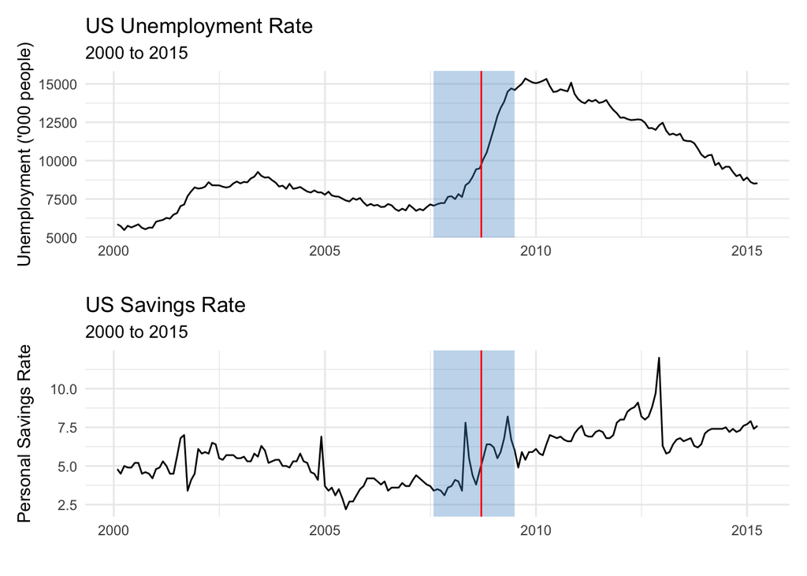

```r
shade_gfc <- data.frame(
  x1 = c(as.Date("2007-08-01")),
  x2 = c(as.Date("2009-07-01")),
  min = c(-Inf, -Inf), max = c(Inf, Inf))


unemploy <- ggplot() +
  geom_line(data = df, aes(x = date, y = unemploy)) +
  geom_rect(data = shade_gfc, aes(xmin = x1, xmax = x2,
                              ymin = min, ymax = max),
            fill = "steelblue3", alpha = 0.2) +
  geom_vline(xintercept = as.Date("2008-09-15"), color = "red")+
  labs(title = "US Unemployment Rate",
       subtitle = "2000 to 2015",
       x = "",
       y = "Unemployment ('000 people)") +
  theme_minimal()

psave <- ggplot() +
  geom_line(data = df, aes(x = date, y = psavert)) +
  geom_rect(data = shade_gfc, aes(xmin = x1, xmax = x2,
                              ymin = min, ymax = max),
            fill = "steelblue3", alpha = 0.2) +
  geom_vline(xintercept = as.Date("2008-09-15"), color = "red")+
  labs(title = "US Savings Rate",
       subtitle = "2000 to 2015",
       x = "",
       y = "Personal Savings Rate") +
  theme_minimal()

library(patchwork)
unemploy/psave
```

You could improve this further by adjsuting the yaxis of unemployment as shown in the recording.

Other options are to remove the xaxis on the top panel and the title from the bottom panel to make it look more like a combined figure.

## geom_area

As an alternative to a line graph you may want to use an area graph

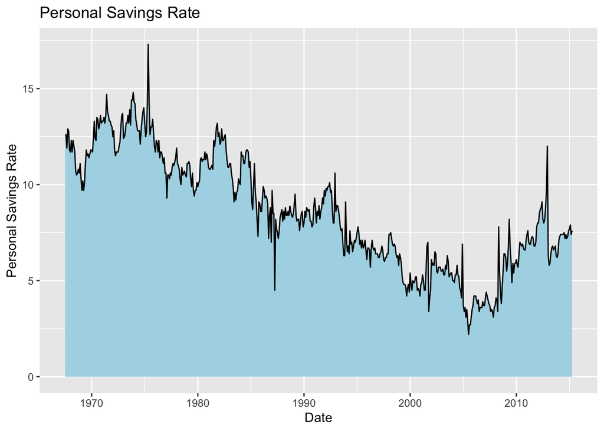

```r
# basic area chart
ggplot(economics) +
  aes(x = date, y = psavert) +
  geom_area(fill="lightblue", color="black") +
  labs(title = "Personal Savings Rate",
       x = "Date",
       y = "Personal Savings Rate")
```

## Stacked area chart

Stacked area chart can be used to show differences between groups over time.

When interest is on both group change over time and overall change over time

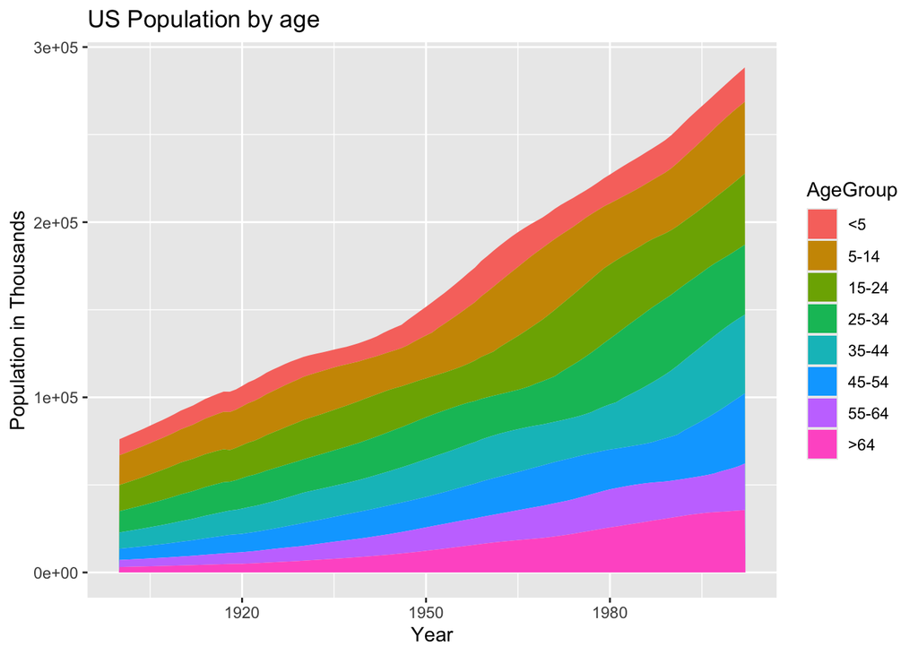

```r
# stacked area chart
# load data
data(uspopage, package = "gcookbook")

ggplot(uspopage) +
  aes(x = Year, y = Thousands, fill = AgeGroup) +
  geom_area() +
  labs(title = "US Population by age",
       x = "Year",
       y = "Population in Thousands")
```

### Try yourself

Using the `economics` dataset, calculate a new variable to represent unemployment as a percentage of the total population.

Make a line graph illustrating this new variable across the whole time series.

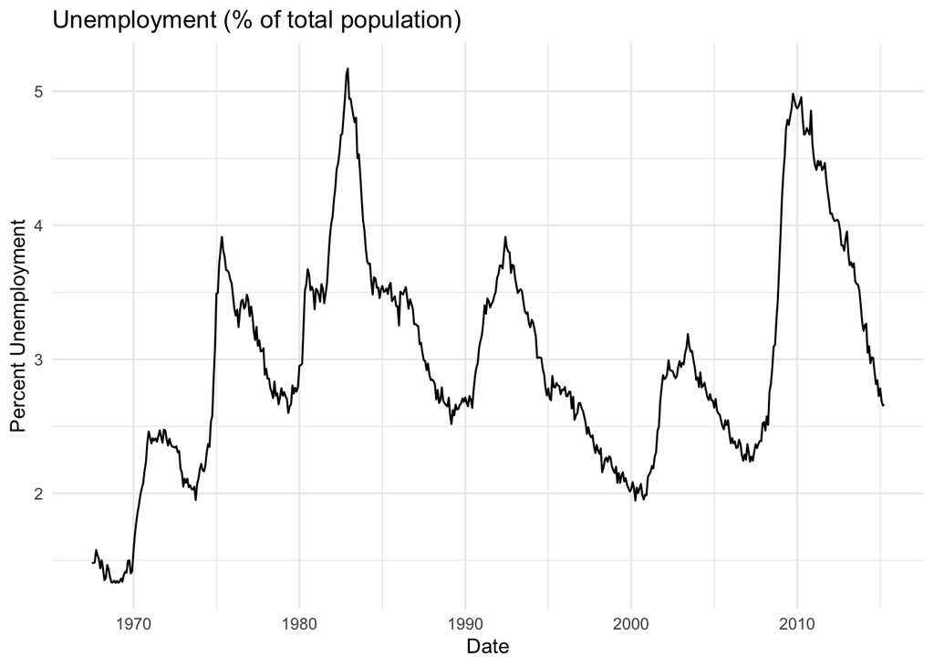

```r
# basic area chart
economics |>
  mutate(per_unemploy = (unemploy/pop)*100) |>
ggplot() +
  aes(x = date, y = per_unemploy) +
  geom_line()+
  labs(title = "Unemployment (% of total population)",
       x = "Date",
       y = "Percent Unemployment") +
  theme_minimal()
```

### Try yourself

Calculate a median annual unemployment and make an area graph illustrating this across the whole time series.

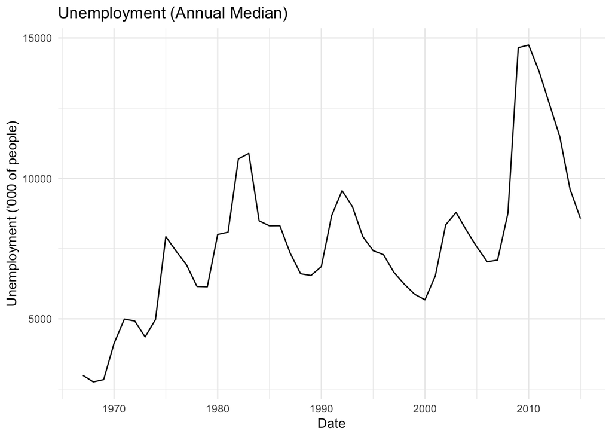

```r
# basic area chart
economics |>
  mutate(year = year(date)) |>
  group_by(year) |>
  mutate(annual_unemploy = median(unemploy)) |>
ggplot() +
  aes(x = year, y = annual_unemploy) +
  geom_line()+
  labs(title = "Unemployment (Annual Median)",
       x = "Date",
       y = "Unemployment ('000 of people)") +
  theme_minimal()
```

## Additional examples

https://r-charts.com/evolution/time-series-ggplot2/

https://r4ds.hadley.nz/datetimes.html

https://codepointtech.com/mastering-tidyverse-for-time-series-analysis-in-r/

## Finishing up

As this is a Quarto document, we can **Render** it to a nice, self-contained .HTML report.

**Make sure you can Render your full document successfully.**